# Synthesis — reference bias, its mechanism, and iterative mapping (s01–s08)

gwct

10/28/2026 12:14 EDT

```r
knitr::opts_chunk$set(echo = TRUE, warning = FALSE, message = FALSE, fig.align = "center")
library(ggplot2); library(dplyr); library(tidyr); library(readr)
source("analyses/lib/design.r")
callers <- c("gatk", "bcftools", "freebayes")
fac <- function(x) factor(x, levels = callers)
pct <- scales::percent
```

**Provenance**

- **Rendered from commit** `5a622987dc70` (branch `mason2-sims`) on 2026-10-28 12:14
- **This notebook:** notebook as committed
- **Analysis code:** no uncommitted edits under `analyses/`
- Each data file’s producing script and command: the section’s `MANIFEST.yaml`

# 1 The one idea

This document pulls the eight sections (s01–s08) onto a single spine so the whole argument is visible in one place. The spine is:

> **Reference bias is two failures — reads that don’t *map*, and reads that map but don’t get *called*. Divergence, indels, heterozygosity, and the spatial structure of divergence all shift the balance between those two. Iterative mapping fixes the parts that are about the *sample’s divergence* (by baking recovered variants into the consensus, lowering the effective divergence), and it cannot fix the parts that are about the *reference’s structure* (structural variants, repeats).**

Everything below is an instance of that sentence:

| section | what it adds | which failure | iteration? |
| --- | --- | --- | --- |
| s01 | SNP divergence (baseline) | both | recovers |
| s02 | indels | mostly mapping (spanning reads) | recovers, most of all |
| s03 | heterozygosity | mapping (alt-read exclusion) | corrects allele balance |
| s05 | heterogeneous divergence | redistributes along local D; *the* mapping-vs-calling split | mechanism unchanged (separable) |
| s06 | variant filtering | acts on *emitted* calls only | can’t recover un-emitted loss |
| s07 | structural variants | reference-structure mapping loss | **cannot** (blind spot) |
| s08 | reference repeats | reference-structure mapping loss | **partly** |

All results are chr19, 30×, `mason` simulation → `bwa` → gatk / bcftools / freebayes, scored against a controlled truth. Single seed unless noted (s01 showed aggregate recall is near-deterministic across seeds).

# 2 Methods — how the simulations were done

Brief but complete: everything needed to reproduce the pipeline. Each box is one stage; the per-plot **SIM DATA** banners state which variants a given figure’s simulation contained.

#### 2.0.0.1 1 · Simulation — controlled truth, then `mason2` reads

- **Reference:** mouse **mm39** (GRCm39), **chr19 only** (for speed, per the project guide).
- **Truth variants** written by `make_truth_vcf.py` onto the reference:
  - **Divergent SNPs** at rate **D** — fixed differences, genotype **1|1**, with independent random alt alleles (the sample-vs-reference divergence axis).
  - **Heterozygous SNPs** at **0.5%** (genotype 0|1) — held fixed throughout.
  - **Indels** (added in s02, s05): 1–10 bp, 50/50 insertion/deletion, indel:SNP ratio ≈ **0.12**, so indel load scales with D on one axis.
  - **Structural variants** (s07 only): larger insertions/deletions placed first to reserve their spans, on a low SNP+indel background.
  - **Heterogeneous divergence** (s05 only): a continuous autocorrelated field (FFT-smoothed, weighted sampling) sets *where* the fixed differences fall, with the genome-wide **mean pinned to D** so only the spatial structure differs from a homogeneous run.
- **Reads:** `mason_simulator` applies the truth VCF to the reference and simulates **150 bp paired-end** reads, **fragment mean 300 bp**, **30×** coverage, **seed 42** (s01 also 43/44 for error bars). Mason’s `-oa` output records each read’s true origin — the ground truth for the ledger.

#### 2.0.0.2 2 · Mapping & iterative refinement (pseudo-it style)

- Reads mapped to the mm39 reference with **`bwa mem`**.
- **Iterative mapping, 3 rounds:** each round calls variants, bakes the recovered variants into the reference with **`bcftools consensus`**, and remaps to that consensus; coordinates are lifted back to reference space for scoring. **Iteration 1 = single-shot** (standard mapping to the original reference); iterations 2–3 map to the progressively updated consensus.
- Because indels shift downstream coordinates, s02+ lift every consensus back to reference coordinates before scoring (**Picard** for VCFs, **point-lift** for BAMs).

#### 2.0.0.3 3 · Variant calling & scoring

- **Three callers, every iteration:** **GATK HaplotypeCaller** (scatter 8), **bcftools** (mpileup/call), **freebayes**. Read **MAPQ floor 20** for all three.
- A truth variant is **recovered** if the caller emitted the matching genotype (position + allele; indels normalized/lifted). **Recall = recovered / truth 1|1 sites** (the divergence-recovery axis).

#### 2.0.0.4 4 · Per-variant mapping-vs-calling ledger

- `variant_read_fate.py` joins each divergent SNP’s **call fate** to its **read-placement fate**, using the `mason -oa` truth BAM to know which reads *should* cover the site (arrived / soft-clipped / mismapped / unmapped).
- `--pileup` classifies each unrecovered site: **calling-limited** (≥2 alt reads present at the site but not emitted) vs **mapping-limited** (alt reads never placed).
- Calling-side context: **static** per-site covariates (`calling_metrics.py`, ±100 bp) and the **dynamic** local unrecovered-neighbour load (`neighborhood_assembly.py`, ±200 bp, per iteration).

#### 2.0.0.5 5 · Section-specific setups

- **s01** baseline (SNPs only) · **s02** + indels · **s03** heterozygous-site allele bias (reuses the s01/s02 BAMs) · **s05** heterogeneous divergence field (mean pinned to D) · **s06** hard-filter sweep on the existing s01/s02 calls · **s07** structural variants · **s08** recovery stratified by reference mappability (**GenMap**, K=100, E=2).

# 3 The problem: divergence loses true variants

Recall of true fixed differences falls as the sample diverges from the reference — this is reference bias. It is caller-dependent, and in a *realistic* (spatially heterogeneous, capped, with correlated heterozygosity) genome it is markedly worse than the homogeneous number suggests.

SIM DATA — chr19, 30× · single-shot recall · **SNPs** (solid) & **indels** (dashed) · homogeneous (grey): **s01** SNP / **s02** indel · realistic-heterogeneous capped (orange): **s05** SNP mean-sweep + indel mean-sweep

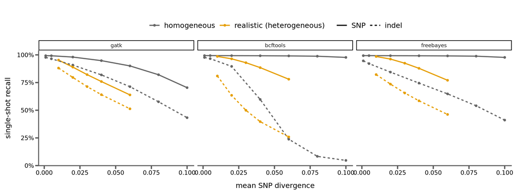

```r
# homogeneous SNP recall (s01, pure baseline) and homogeneous INDEL recall (s02, the SNP+indel sim)
snp_homog <- read_csv("analyses/s01-baseline-iterative/results/s01-base-iterative-summary.csv") %>%
  filter(iteration == 1, divergence > 0) %>%
  group_by(caller, divergence) %>% summarize(recall = mean(div_tp / n_truth_div), .groups = "drop") %>%
  mutate(scenario = "homogeneous", variant = "SNP")
ind_homog <- read_csv("analyses/s02-indels/results/s02-indels-recovery-summary.csv") %>%
  filter(iteration == 1, divergence > 0) %>%
  group_by(caller, divergence) %>%
  summarize(recall = mean(indel_div_tp / n_truth_indel_div), .groups = "drop") %>%
  mutate(scenario = "homogeneous", variant = "indel")
# realistic (heterogeneous, capped) SNP recall (s05 SNP-only mean-sweep) and INDEL recall
# (s05 realistic mean-sweep WITH indels, job 39190833) -- same field, indels on the field
snp_real <- read_csv("analyses/s05-heterogeneous-divergence/results/s05-realistic-meansweep-iterative-summary.csv") %>%
  filter(iteration == 1) %>%
  group_by(caller, divergence) %>% summarize(recall = mean(div_tp / n_truth_div), .groups = "drop") %>%
  mutate(scenario = "realistic (heterogeneous)", variant = "SNP")
ind_real <- read_csv("analyses/s05-heterogeneous-divergence/results/s05-realistic-meansweep-indels-recovery-summary.csv") %>%
  filter(iteration == 1) %>%
  group_by(caller, divergence) %>%
  summarize(recall = mean(indel_div_tp / n_truth_indel_div), .groups = "drop") %>%
  mutate(scenario = "realistic (heterogeneous)", variant = "indel")

prob <- bind_rows(snp_homog, ind_homog, snp_real, ind_real) %>%
  mutate(caller = fac(caller),
         scenario = factor(scenario, levels = c("homogeneous", "realistic (heterogeneous)")),
         variant = factor(variant, levels = c("SNP", "indel")))
ggplot(prob, aes(divergence, recall, color = scenario, linetype = variant,
                 group = interaction(scenario, variant))) +
  geom_line(linewidth = 0.9) + geom_point(size = 1.4) +
  scale_color_manual(values = c(homogeneous = "grey40",
                                `realistic (heterogeneous)` = corecol(pal="wilke",numcol=5)[1]), name = NULL) +
  scale_linetype_manual(values = c(SNP = "solid", indel = "22"), name = NULL) +
  scale_y_continuous(labels = pct) + facet_wrap(~caller, nrow = 1) +
  labs(x = "mean SNP divergence", y = "single-shot recall") +
  bartheme() + theme(legend.position = "top")
```

**Read:** loss grows with divergence; gatk loses most. **Two axes each make it worse, and they stack.** In *both* scenarios, **indels (dashed) are recovered worse than SNPs (solid)** — dramatically so for bcftools, which collapses on them; and in *both* variant types the **realistic-heterogeneous curve (orange) sits below the homogeneous one (grey)**. So the true worst case — realistic divergence *with* indels (orange dashed) — is far below what a homogeneous, SNP-only view would suggest. That stacked gap is the first reason the rest of the paper matters.

# 4 The fix: iterative mapping

Iteration maps to a consensus that has absorbed the divergence recovered so far, lowering the *effective* divergence each round. It recovers both failure modes from the spine — the sites a caller could not emit (better local assembly) and the divergence-driven sites whose reads would not place (reads now map). Recall rises and converges by ~iteration 3, most for the caller that was worst (gatk). *Why* it works — which reads and calls change — is the mechanism dissected in the next section.

SIM DATA — chr19, 30× · **s01** · SNPs only · homogeneous divergence

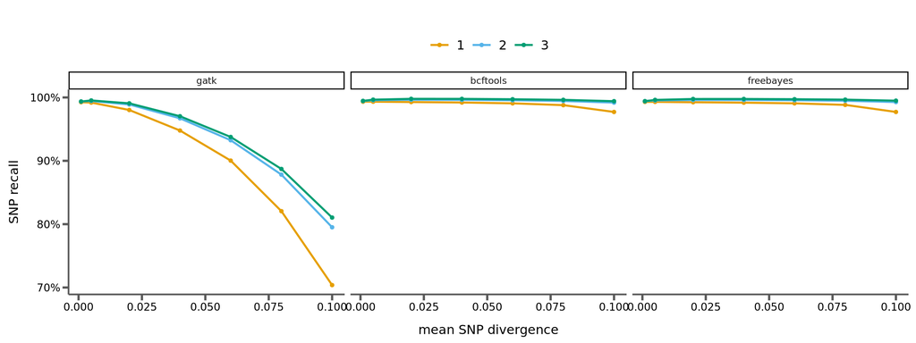

```r
gains <- read_csv("analyses/s01-baseline-iterative/results/s01-base-iterative-summary.csv") %>%
  filter(divergence > 0) %>%
  group_by(caller, divergence, iteration) %>%
  summarize(recall = mean(div_tp / n_truth_div), .groups = "drop") %>%
  mutate(caller = fac(caller), iteration = factor(iteration))
ggplot(gains, aes(divergence, recall, color = iteration)) +
  geom_line(linewidth = 0.9) + geom_point(size = 1.3) +
  scale_color_manual(values = corecol(pal = "wilke", numcol = 3), name = "iteration") +
  scale_y_continuous(labels = pct) + facet_wrap(~caller, nrow = 1) +
  labs(x = "mean SNP divergence", y = "SNP recall") +
  bartheme() + theme(legend.position = "top")
```

**Read:** gatk gains most (e.g. +10 pt at D = 0.10), pulling toward the pileup callers; bcftools/ freebayes start near the ceiling. The per-fate read-level decomposition (next section) shows *why*: the sites that flip to called are exactly those whose reads improve across iterations.

# 5 The mechanism: mapping vs. calling

The crux. A lost variant is lost for one of two reasons — the alt-carrying reads never **map** to the site (clipped/mismapped, so the evidence is absent = **mapping-limited**), or they map but the caller doesn’t **call** the variant (the alt *is* in the pileup = **calling-limited**). Which one dominates differs by caller and by regime, and it is the through-line of every section. `y` below is the **share of divergent sites** in each bin falling in each outcome (the three sum to 100 %).

## 5.1 Quantified: two regimes

The read-level ledger (`variant_read_fate.py --pileup`) classifies every divergent site. On **homogeneous** divergence (s01, ≤ 0.10) the loss is almost entirely **calling-limited** — even at D = 0.10 the reads still place; it is gatk’s reassembler that fails (mapping-limited stays ~1 %):

SIM DATA — chr19, 30× · **s01** · SNPs only · homogeneous divergence

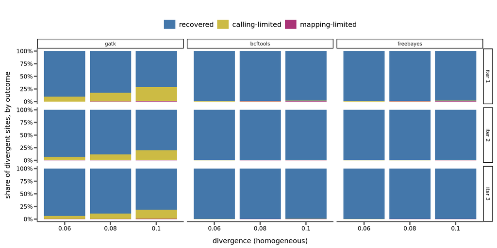

```r
s01mvc <- read_csv("analyses/synthesis/s01-mapping-vs-calling.csv") %>%
  mutate(caller = fac(caller), iteration = factor(paste("iter", iteration)),
         class = factor(class, levels = c("recovered","calling-limited","mapping-limited")))
ggplot(s01mvc, aes(factor(divergence), frac, fill = class)) +
  geom_col(width = 0.9) +
  scale_fill_manual(values = c(recovered="#4477AA", `calling-limited`="#CCBB44",
                               `mapping-limited`="#AA3377"), name = NULL) +
  scale_y_continuous(labels = pct) + facet_grid(iteration ~ caller) +
  labs(x = "divergence (homogeneous)", y = "share of divergent sites, by outcome") +
  bartheme() + theme(legend.position = "top")
```

The **mapping-limited** wall appears only at the high *local* divergences that spatial heterogeneity produces (s05) — where a 150 bp read carries too many mismatches to place at all. Before reading the realistic capped run on that axis, look at how divergence is actually distributed in it.

SIM DATA — chr19, 30× · **s05** · same realistic capped config (mean D = 0.03) — per-read & per-site divergence QC

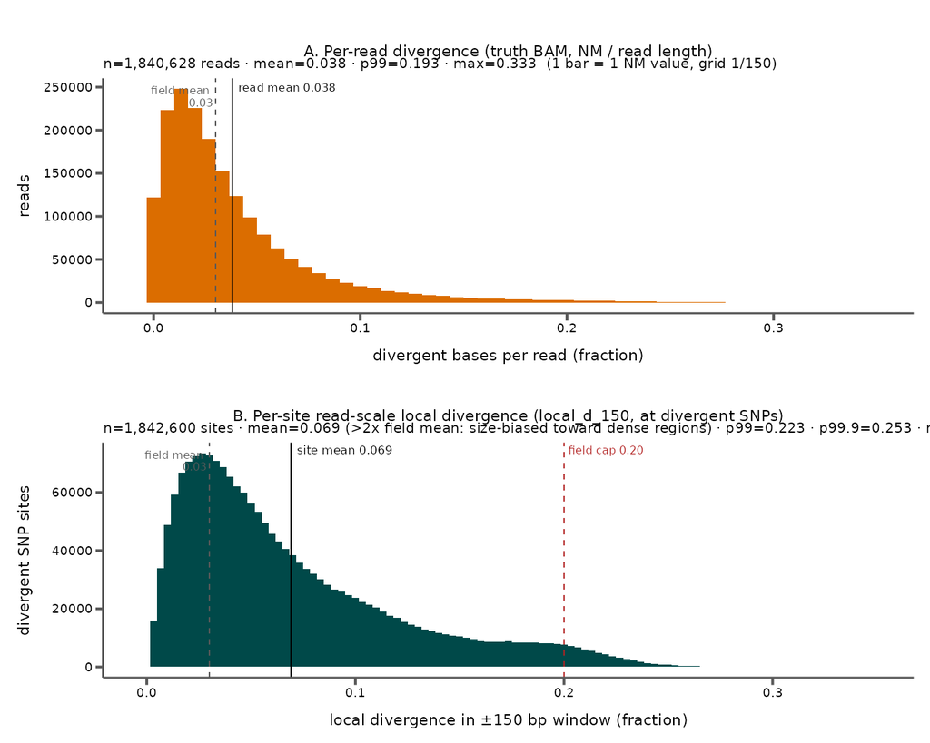

Now the mapping-vs-calling split across that **read-scale local-divergence** axis — the **actual realistic capped run** (mean D = 0.03), not a truncated characterization plot. The dashed line at 0.20 is the divergence-**field** cap (the read-scale axis runs a little past it, as the distribution above shows). The full transition is visible (iterations 1/2/3 as rows):

SIM DATA — chr19, 30× · **s05** · SNPs + het on a heterogeneous (autocorrelated) divergence field · realistic capped config, mean D = 0.03 (SNP-only; the indel version is running)

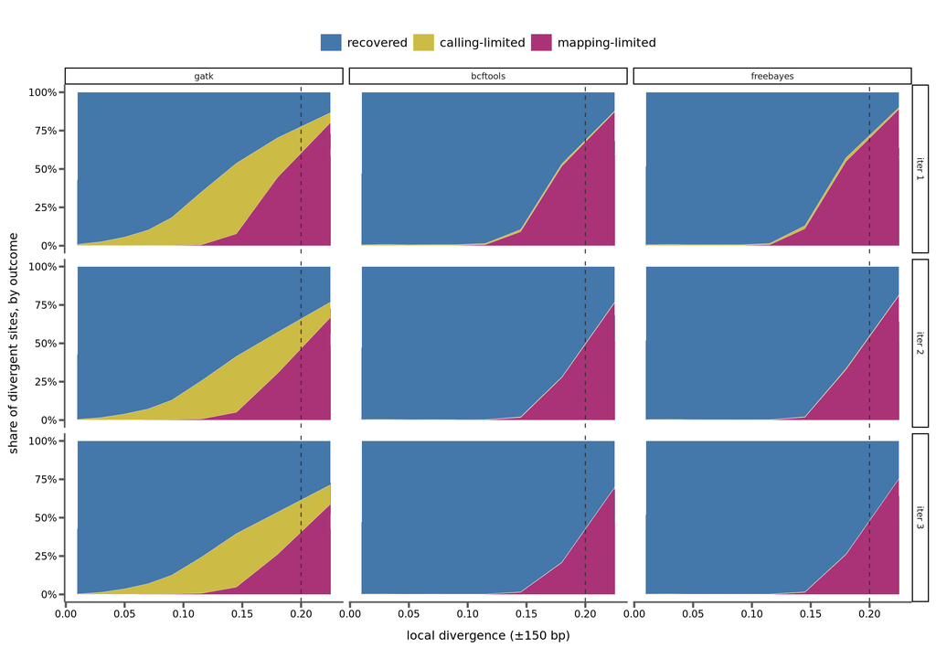

```r
mvc <- read_csv("analyses/s05-heterogeneous-divergence/results/s05-mapping-vs-calling-capped.csv") %>%
  filter(window == 150, iteration %in% c(1, 2, 3), n_sites > 50, locald_mid <= 0.25) %>%
  transmute(caller = fac(caller), iteration = factor(paste("iter", iteration)), locald_mid,
            recovered = frac_recovered, `calling-limited` = frac_calling,
            `mapping-limited` = frac_mapping) %>%
  pivot_longer(c(recovered, `calling-limited`, `mapping-limited`),
               names_to = "class", values_to = "frac") %>%
  mutate(class = factor(class, levels = c("recovered","calling-limited","mapping-limited")))
ggplot(mvc, aes(locald_mid, frac, fill = class)) +
  geom_area(color = "white", linewidth = 0.1) +
  geom_vline(xintercept = 0.20, linetype = "dashed", color = "grey20") +
  scale_fill_manual(values = c(recovered="#4477AA", `calling-limited`="#CCBB44",
                               `mapping-limited`="#AA3377"), name = NULL) +
  scale_y_continuous(labels = pct) + facet_grid(iteration ~ caller) +
  labs(x = "local divergence (±150 bp)", y = "share of divergent sites, by outcome") +
  bartheme() + theme(legend.position = "top")
```

*(The calling→mapping crossover (~0.16) matches the uncapped characterization config (s05 notebook), confirming the split is a property of the caller + read length, not the field. Beyond ~0.18 is the mapping wall, where reads stop placing for every caller.)*

**Read.** *Columns (callers):* bcftools/freebayes loss is ~entirely **mapping-limited** (the amber calling band is absent); **gatk** adds a wide **calling-limited** band. *Rows (iterations):* the coloured bands shrink and blue “recovered” grows — iteration lowers effective divergence so reads place (mapping) and the reassembly becomes tractable (calling). *The two regimes:* homogeneous ≤ 0.10 lives in the calling-limited zone; the mapping-limited wall needs the high local divergences heterogeneity creates. This split is the project’s unifying lens — s02/s03 losses are mapping-limited (spanning reads, alt-read exclusion), and the off-axis limits (s07 SVs, s08 repeats) are mapping-limited failures the sample’s divergence can’t explain.

**GATK’s calling-limited loss concentrates in SNP clusters.** In the uniform s01 simulations, where the number of SNPs near a site varies only by chance, GATK’s single-shot recall at D = 0.10 falls from 75% for SNPs with no other divergent SNP within ±10 bp to 43% for those with six or more, while bcftools and freebayes stay at 95% or more until that densest bin. Iteration lifts GATK but leaves the gap (86% vs 50% at iteration 3). Close-packed SNPs leave few k-mers shared with the reference for its re-assembly (s01 notebook, *Recall by local SNP clustering*).

## 5.2 Per variant: the G plots (full sweep)

The joint-state flow diagrams show the same split one SNP at a time — each site’s *called / not-called* state coloured by **f_alt** (how strongly the alt is present in its reads, i.e. whether the evidence arrived), flowing across the three iterations. **Yellow in the “not called” box = calling-limited** (evidence present, uncalled); **dark = mapping-limited** (evidence absent). Full sweep, every caller (rows) × divergence (columns):

SIM DATA — chr19, 30× · **s01** (SNPs only) vs **s02** (SNPs + indels) · both homogeneous divergence

**SNP-only (s01):**

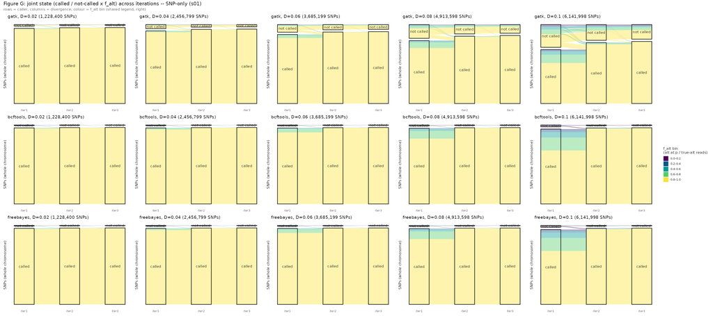

**With indels (s02):**

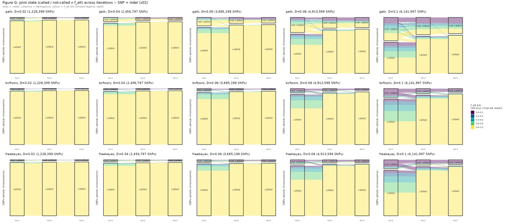

**Read.** In **s01** the “not called” box is dominated by **yellow** — gatk’s calling-limited deficit, which grows with divergence and which iteration flows down into “called.” Adding **indels (s02)** injects a large **dark** band into the not-called box (indel-spanning reads clip, so the alt evidence is absent) that **persists across iterations** — a visible shift from calling-limited toward mapping-limited. That is why indels are the harder problem: they move loss into the mode iteration can’t fully rescue. (Do indels change the G plots? Yes — the not-called box goes from yellow to part-dark.)

## 5.3 Per variant: the read-level decomposition

Zooming into the reads at each site — the companion decomposition. Distributions and mean trends of pileup depth, alt-read support (f_alt), MAPQ, mismapped-in/out reads, and local unrecovered- neighbour load, split by whether a site is **called**, **stays not-called**, or **flips to called** across an iteration (s01). Each metric row is tagged by which failure mode it diagnoses: the read-placement metrics (**· mapping ·** — depth, f_alt, ref reads, mismapped-in/out, MAPQ) say whether the alt reads *arrived*; the assemblable-neighbourhood load (**· CALLING ·** — unrecovered neighbour SNPs) says whether gatk’s reassembler could *act*.

### 5.3.1 Per-SNP metric dictionary

Every per-SNP metric used in the decomposition (plus the neighbour-indel metric from the Indels section). **Dynamic** metrics are recomputed per caller × iteration (they *move* as iteration re-maps and re-calls) and appear in the before→after boxplots/means; **static** metrics are fixed properties of the site (they never change across iterations) and appear in the fate-grouped figures. The **Caller most affected** and **Iteration helps?** columns summarise which caller each factor hits hardest and whether iteration mitigates it (green = yes, amber = partial, red = no, grey = n/a).

| Metric (row label) | Mode | Window | Caller most affected | Iteration helps? | Definition — and what it proxies |
| --- | --- | --- | --- | --- | --- |
| **Dynamic — recomputed per caller × iteration (before→after boxplots / means)** |  |  |  |  |  |
| depth at p | · mapping · | at p | all ~equally (shared mapping) | yes — rises | Total reads covering the SNP position p. Low depth = reads failed to place. |
| f_alt | · mapping · | at p | all ~equally (shared mapping) | yes — rises | Fraction of the site’s true alt reads that arrived at p and support alt. The core “did the evidence arrive?” measure. |
| ref reads at p | · mapping · | at p | all ~equally | yes — falls | Reads at p supporting the reference allele. High ref with low alt at a divergent site = reference bias. |
| mismapped-in ref | · mapping · | at p | all ~equally | yes — falls | Foreign reads mismapped into p carrying the reference allele — contamination that dilutes alt support. |
| mismapped-out | · mapping · | at p | all ~equally | yes — falls | The site’s own true alt reads that went missing — mapped to another locus/chromosome, or unmapped. |
| mean MAPQ at p | · mapping · | at p | all ~equally | yes — rises | Mean mapping quality of reads at p. Low MAPQ = ambiguous placement in a divergent/repetitive region. |
| neighbor unrec SNPs (±200bp) | · CALLING · | ±200 bp | gatk most (its assembler) | yes — falls (the rescue) | Neighbour divergent SNPs not yet recovered by this caller at this iteration. Falls as iteration bakes neighbours into the consensus — the assemblable context that lets gatk call. |
| neighbor unrec indels (±200bp) | · CALLING · | ±200 bp | bcftools worst single-shot; freebayes stuck | partial — big residual | Indel analogue of the row above (see the Indels section). Falls with iteration but leaves a much larger residual than SNPs — indels are cleared less completely. |
| **Static — fixed site property, never changes across iterations (fate-grouped figures)** |  |  |  |  |  |
| homopolymer frac (≥5bp) | · CALLING · | ±100 bp | gatk only (its assembler) | no — sequence, not divergence | Fraction of the window inside a homopolymer run ≥5 bp (e.g. AAAAA). Low-complexity sequence that stalls gatk’s reassembler. |
| indel density (/bp) | · mapping · | ±100 bp | all; bcftools worst | partial — cleared incompletely | Indel truth sites per bp in the window. Nearby indels defeat placement (spanning reads clip); iteration only partly clears them. |
| div-SNP density (/bp) | · mapping · | ±100 bp | all callers | yes — effective D drops | Divergent (1\|1) truth SNPs per bp, incl. self. TOTAL local divergence load; iteration lowers the effective divergence. |
| het-SNP density (/bp) | · CALLING · | ±100 bp | minimal (flat here) | n/a — inactive at 0.5% het | Heterozygous truth SNPs per bp. Local genotyping/phasing complexity (flat at this project’s 0.5% het rate). |

*Fate categories used to split the plots.* **Iteration fate** (before→after boxplots/means, and the iteration-fate figure): *stayed not-called* / *flip (→called)* / *stayed called* across iterations 1→2. **Single-shot fate** (the mapping-vs-calling figure and calling-covariate-by-fate figure): *recovered* (called) / *calling-limited* (≥2 alt reads present at *p* but not emitted) / *mapping-limited* (alt reads never placed, < 2 present).

**Distributions by fate (boxplots), across divergence:**

SIM DATA — chr19, 30× · **s01** · SNPs only · homogeneous divergence · 0.5% het — dynamic read-level metrics (this boxplot and the means below)

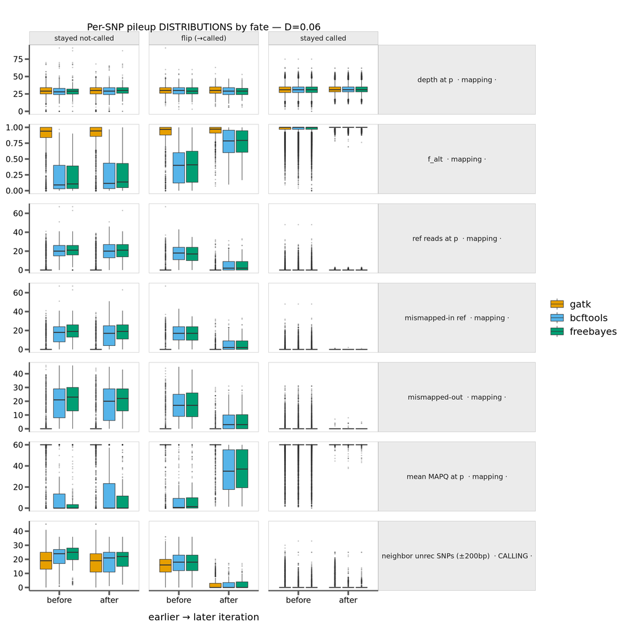

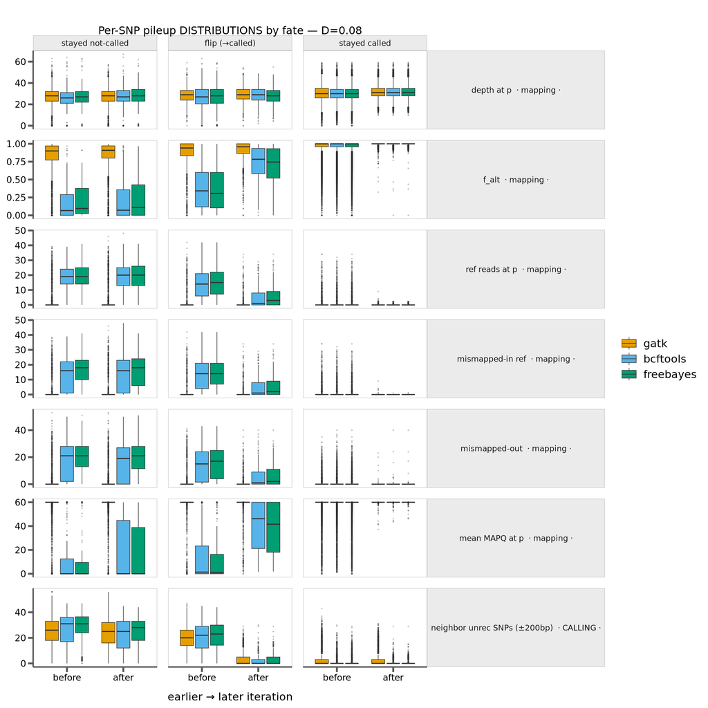

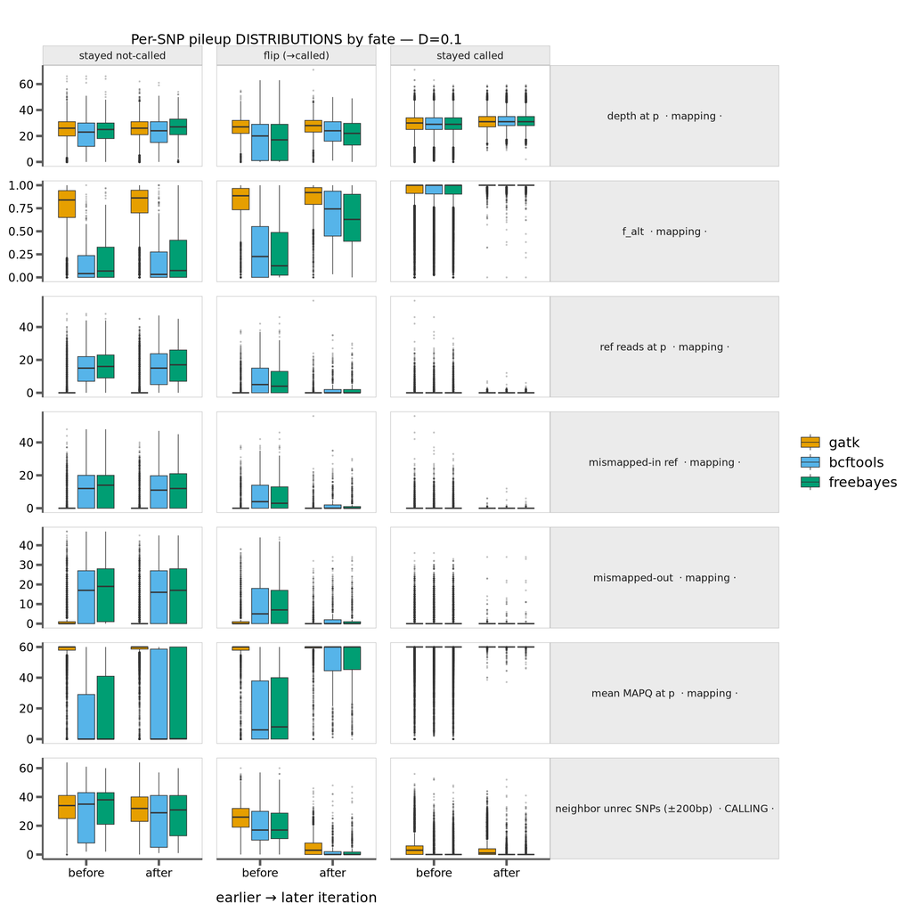

**Mean direction-of-change, per fate:**

SIM DATA — chr19, 30× · **s01** · SNPs only · homogeneous divergence · 0.5% het

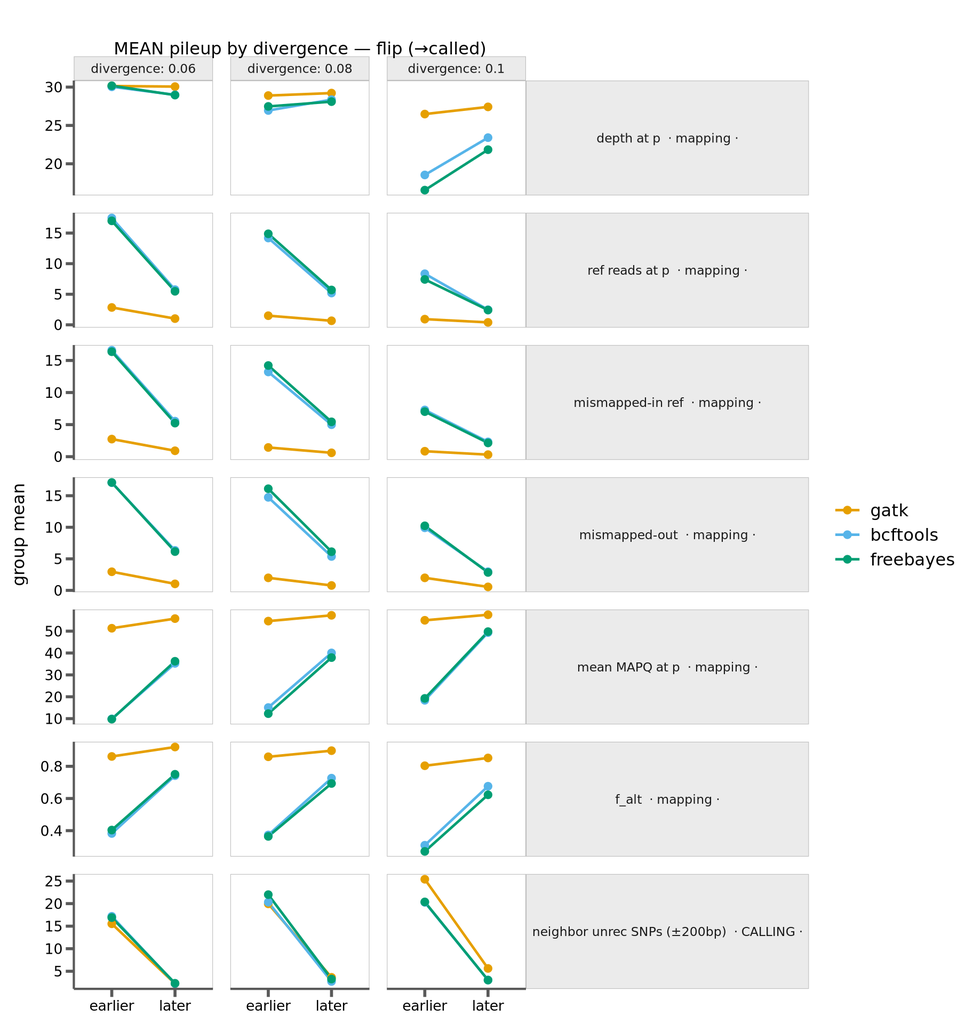

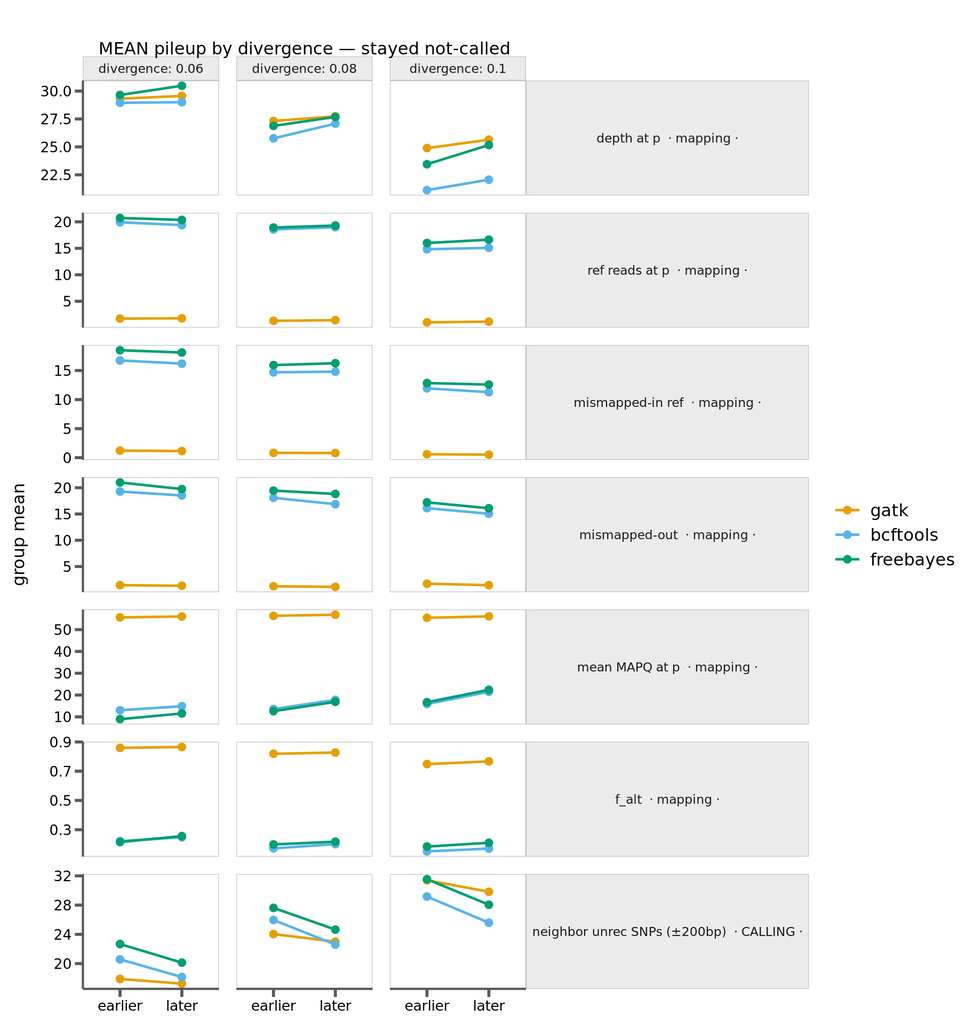

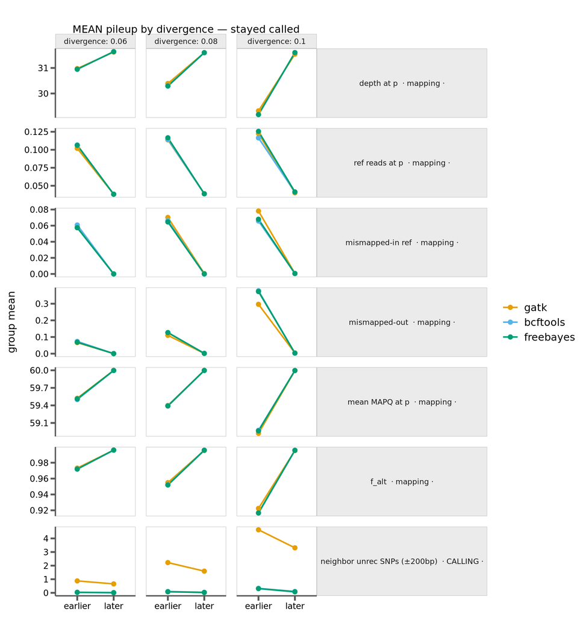

**Read:** sites that *flip to called* are exactly those where, between iterations, the pileup at the site cleans up — alt-read support and MAPQ rise and the local load of *unrecovered* neighbouring SNPs falls — while *stayed-not-called* sites don’t improve on those axes, and *stayed-called* sites were already clean. That is iteration lowering the effective divergence around each site until the caller can act: the mechanism of the fix, measured read by read.

**What makes a site calling-limited vs mapping-limited.** The plots above track pileup metrics that *move* across iterations. But some determinants are **static** — intrinsic sequence/variant context that never changes with iteration — so they are read on the single-shot three-way fate instead: **recovered** / **calling-limited** (≥2 alt reads present but never emitted) / **mapping-limited** (alt reads never placed). Computed on **s02** (indels present, the key calling stressor) over a ±100 bp window per divergent SNP by `calling_metrics.py`; each metric row is again tagged by the failure mode it separates. Shown as **means with 95% CIs** (not boxplots): these covariates are zero-inflated and right-skewed, so the calling signal lives in the *upper tail* — it moves the mean but not the median, and a boxplot’s median/IQR would hide it entirely (verified directly).

SIM DATA — chr19, 30× · **s02** · SNPs + indels · homogeneous divergence · 0.5% het — static calling covariates (this figure and the iteration-fate one below)

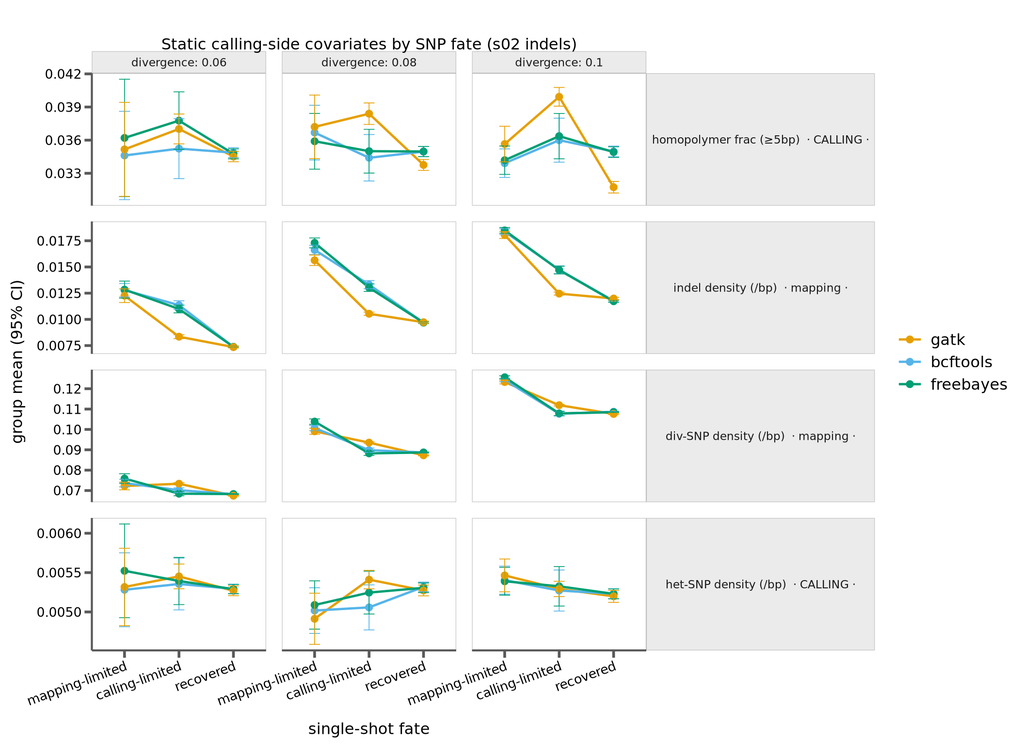

**Read:** the two failure modes have *different* local fingerprints. **Homopolymer/low-complexity content (· CALLING ·)** is elevated specifically at **gatk’s calling-limited** sites — the alt reads are present, but low-complexity sequence stalls gatk’s local reassembler — and the gap over recovered sites *widens* with divergence (+0.0025 → +0.0046 → +0.0082 from D = 0.06 → 0.10), while bcftools and freebayes (which call straight from the pileup) show no such separation. **Indel and div-SNP density (· mapping ·)** instead peak at **mapping-limited** sites for *every* caller — dense divergence and nearby indels defeat *placement*, upstream of calling. Het density is flat: at a 0.5 % het rate this calling axis is inactive. This turns the single “unrecovered-neighbour SNPs” calling metric into a three-axis calling-side picture — assembly load (variants), resolvability (sequence), and genotyping (haplotypes) — and confirms the spine at the level of *why an individual site* lands in each bin.

**Does static context predict what iteration can rescue?** The same covariates, now grouped by the **iteration** fate (does a site *stay not-called*, *flip to called*, or *stay called* from iter 1 → 2) rather than the single-shot fate. These are static properties, so there is no before/after — but the grouping asks a sharp question: is a site’s rescuability written into its local context?

SIM DATA — chr19, 30× · **s02** · SNPs + indels · homogeneous divergence · 0.5% het

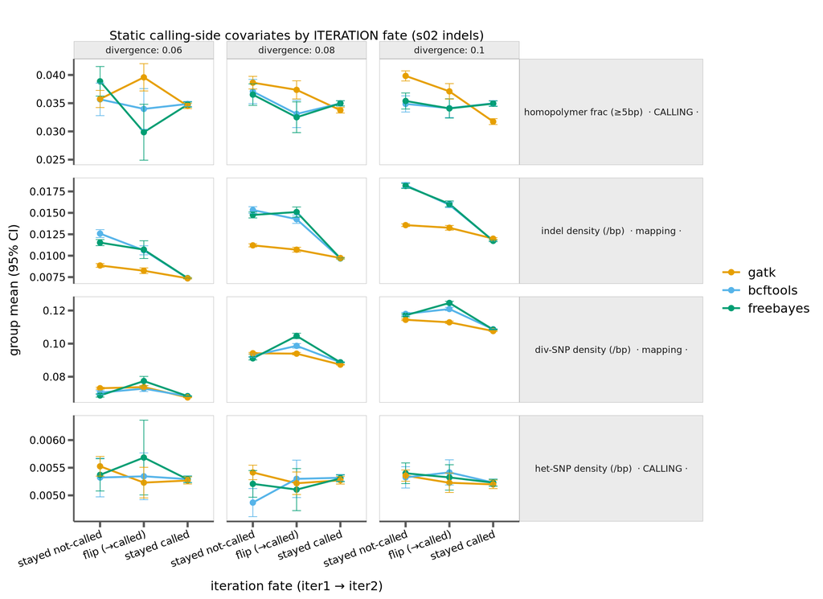

**Read:** yes — and the two axes split by *rescuability*. **div-SNP density (· mapping ·) peaks at the sites that flip to called**: divergence-dense neighbourhoods are exactly what iteration fixes, by lowering the effective divergence until reads place. But **indel density (· mapping ·) and homopolymer content (· CALLING ·) are highest at the sites that stay not-called** — for gatk, homopolymer falls monotonically 0.040 (stayed not-called) → 0.037 (flip) → 0.032 (stayed called). Those are the failures iteration *cannot* touch: it changes the effective divergence, not the reference’s indels or its low-complexity sequence. So iteration’s ceiling is set by static context — it clears the divergence-driven loss and leaves the structure/sequence-driven loss behind, the same boundary the s07 (SVs) and s08 (repeats) limits sit on.

# 6 What each axis does to the picture

The scenarios are not separate stories — each just shifts the same mapping/calling balance.

## 6.1 Indels — worse loss, bigger rescue (s02)

Indels are the worst mapping case (a read spanning an unrepresented indel clips), so single-shot indel recovery is very low — and iteration rescues them *more* than SNPs (the caller-flip):

SIM DATA — chr19, 30× · **s02** · SNPs + indels · homogeneous divergence · 0.5% het

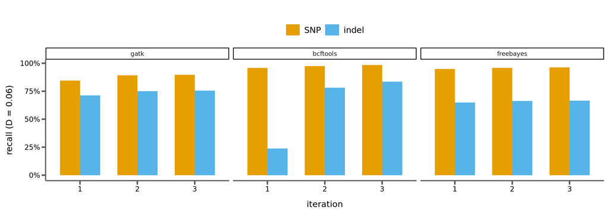

```r
s02 <- read_csv("analyses/s02-indels/results/s02-indels-recovery-summary.csv") %>%
  filter(divergence == "0.06") %>%
  transmute(caller = fac(caller), iteration = factor(iteration),
            SNP = div_tp / n_truth_div, indel = indel_div_tp / n_truth_indel_div) %>%
  pivot_longer(c(SNP, indel), names_to = "vtype", values_to = "recall") %>%
  mutate(vtype = factor(vtype, levels = c("SNP","indel")))
ggplot(s02, aes(iteration, recall, fill = vtype)) +
  geom_col(position = "dodge", width = 0.7) +
  scale_fill_manual(values = corecol(pal="wilke",numcol=2), name = NULL) +
  scale_y_continuous(labels = pct) + facet_wrap(~caller, nrow = 1) +
  labs(x = "iteration", y = "recall (D = 0.06)") +
  bartheme() + theme(legend.position = "top")
```

**What iteration clears from the neighbourhood — SNPs vs indels (granular, per site).** The bars above are per-site recall; the mechanism is the local *assemblable neighbourhood* (the read-level decomposition). Here is the neighbour-unrecovered metric for **indels** shown exactly like its SNP counterpart in the read-level decomposition — per-site, split by fate, before→after iteration — with the neighbour-SNP row above the neighbour-indel row for direct comparison (±200 bp window around each divergent SNP; same tool, `neighborhood_assembly.py`; indel recovery is scored by position match of normalized truth vs recovered indels, so it is a slight lower bound).

SIM DATA — chr19, 30× · **s02** · SNPs + indels · homogeneous divergence · 0.5% het

**Distributions by fate (boxplots), across divergence:**

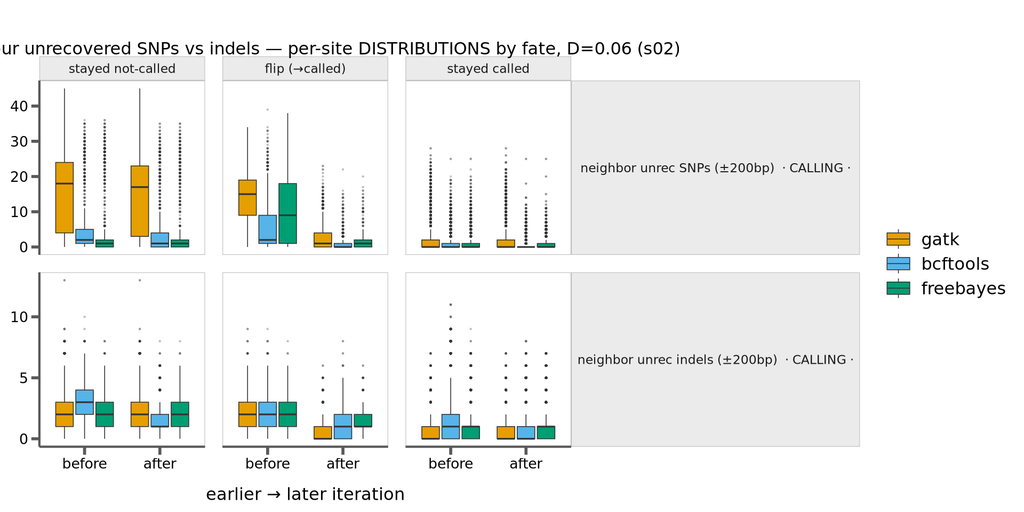

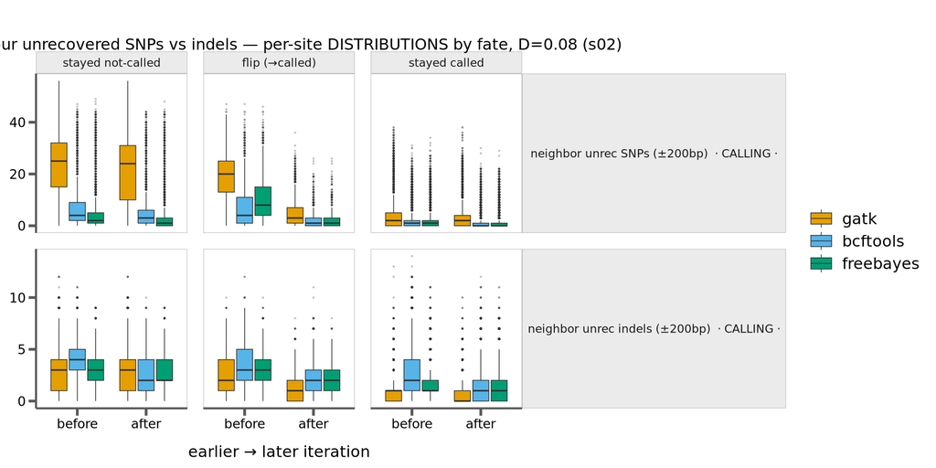

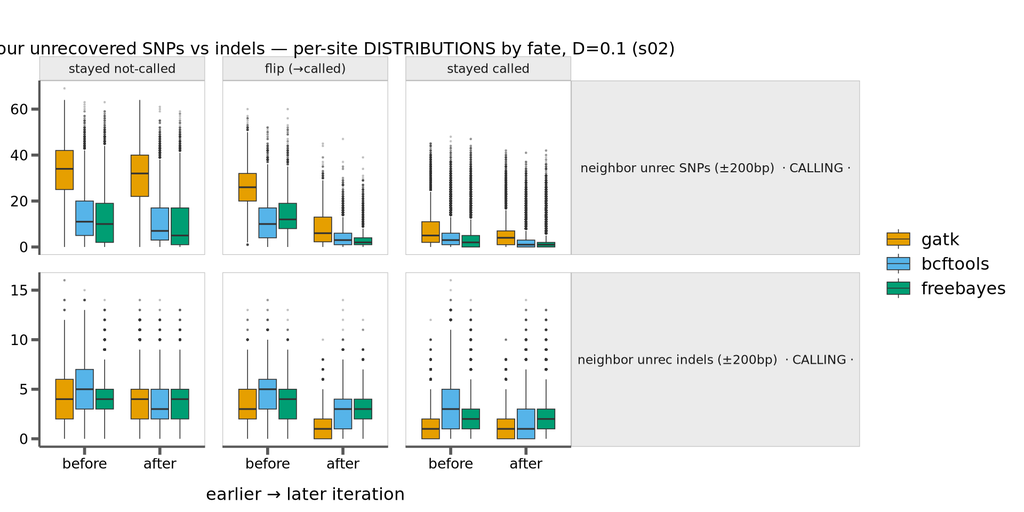

**Mean direction-of-change, per fate:**

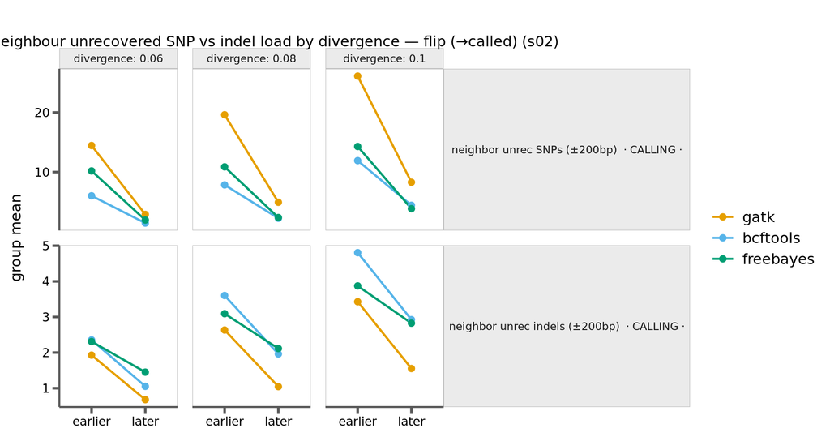

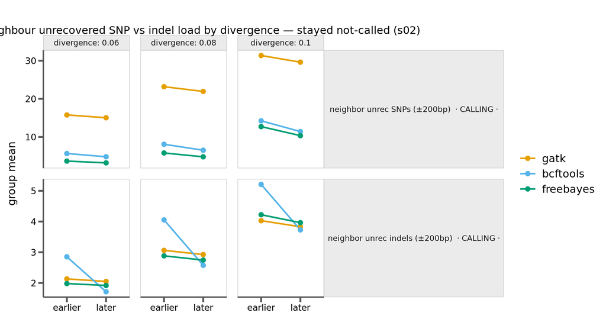

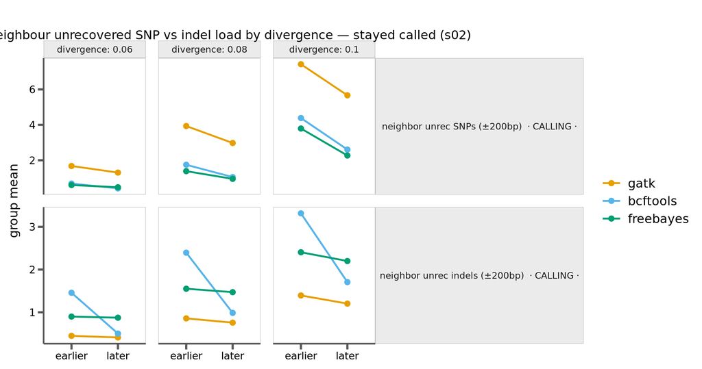

## 6.2 Heterozygosity — reference bias as allele imbalance (s03)

At heterozygous sites the alt allele maps worse, so the pileup skews toward the reference (ref-allele fraction > 0.5). Iteration corrects it back toward 0.5:

SIM DATA — chr19, 30× · **s03** · heterozygous sites measured on the **s01** (SNP-only) and **s02** (SNP + indel) BAMs · homogeneous divergence

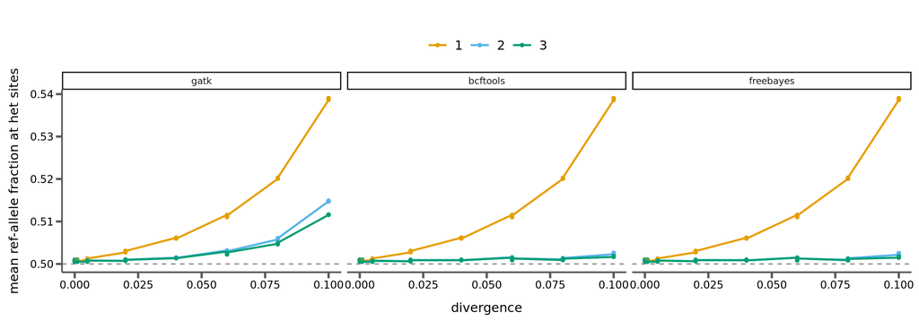

```r
ab <- read_csv("analyses/s03-heterozygosity/results/s03-s01-allele-balance-summary.csv") %>%
  mutate(caller = fac(caller), iteration = factor(iteration))
ggplot(ab, aes(divergence, mean_raf, color = iteration)) +
  geom_hline(yintercept = 0.5, linetype = "dashed", color = "grey50") +
  geom_line(linewidth = 0.9) + geom_point(size = 1.3) +
  scale_color_manual(values = corecol(pal = "wilke", numcol = 3), name = "iteration") +
  facet_wrap(~caller, nrow = 1) +
  labs(x = "divergence", y = "mean ref-allele fraction at het sites") +
  bartheme() + theme(legend.position = "top")
```

## 6.3 Heterogeneous divergence — it’s separable (s05)

Clustering divergence does not create a new phenomenon: recovery vs *local* divergence in a heterogeneous genome (even with indels co-clustered) lies on top of recovery vs *mean* divergence in a homogeneous genome. Heterogeneity only *redistributes* sites along the curve.

SIM DATA — chr19, 30× · **s02** (SNPs + indels) and **s05** (heterogeneous divergence field) · recovery vs measured local divergence

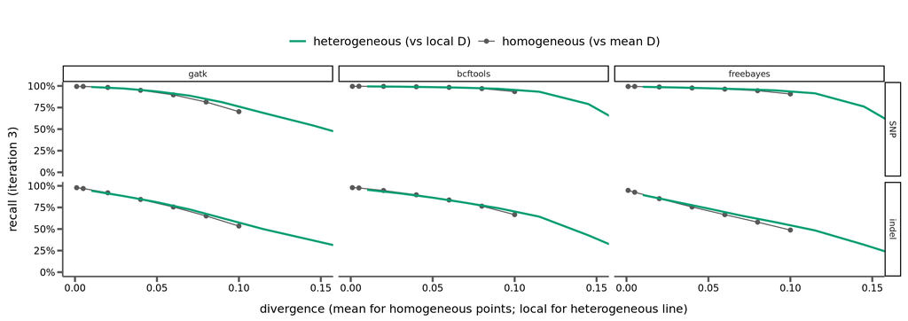

```r
het <- read_csv("analyses/s05-heterogeneous-divergence/results/s05-hetindel-local-recovery.csv") %>%
  filter(iteration == 3, n_sites > 500) %>%
  mutate(caller = fac(caller), vtype = factor(ifelse(vtype=="snp","SNP","indel"), levels=c("SNP","indel")))
hom <- read_csv("analyses/s02-indels/results/s02-indels-recovery-summary.csv") %>%
  filter(iteration == 3, divergence != "0.00") %>%
  mutate(caller = fac(caller), divergence = as.numeric(divergence),
         SNP = div_tp/n_truth_div, indel = indel_div_tp/n_truth_indel_div) %>%
  select(caller, divergence, SNP, indel) %>%
  pivot_longer(c(SNP,indel), names_to="vtype", values_to="recall") %>%
  mutate(vtype = factor(vtype, levels=c("SNP","indel")))
ggplot() +
  geom_line(data = hom, aes(divergence, recall, color = "homogeneous (vs mean D)"), linewidth=0.5) +
  geom_point(data = hom, aes(divergence, recall, color = "homogeneous (vs mean D)"), size=1.8) +
  geom_line(data = het, aes(locald_mid, recall, color = "heterogeneous (vs local D)"), linewidth=1) +
  scale_color_manual(values = c(`homogeneous (vs mean D)`="grey35",
                                `heterogeneous (vs local D)`=corecol(pal="wilke",numcol=5)[3]), name=NULL) +
  scale_y_continuous(labels = pct) + coord_cartesian(xlim = c(0,0.15)) +
  facet_grid(vtype ~ caller) +
  labs(x = "divergence (mean for homogeneous points; local for heterogeneous line)",
       y = "recall (iteration 3)") +
  bartheme() + theme(legend.position = "top")
```

**Read:** the curves coincide → **separable**. The practical payoff: recovery under *any* landscape is predictable from the homogeneous recall-vs-divergence curve plus the local- divergence distribution. No per-landscape simulation needed, and the mechanism above carries over unchanged.

# 7 The limits: what iteration cannot fix

Two failure modes are **off the divergence axis** — they are about the reference, not the sample — so lowering effective divergence doesn’t touch them, and filtering can’t recover them.

## 7.1 You can’t filter your way out (s06)

Hard filters only *remove* calls, so recall can only fall — the lost variants are un-emitted, not low-quality entries. Filtering buys precision (mostly for freebayes’ over-calls), never recall, and aggressive MAPQ filtering *amplifies* bias by deleting the diverged reads.

SIM DATA — chr19, 30× · **s06** · SNP filters on **s01** (SNP-only), indel filters on **s02** (SNP + indel) · homogeneous divergence · hard-filter sweep

**How to read the QUAL panel.** It is a recall–precision *trace*, not a threshold-on-x plot: the filter threshold is encoded along each path. One point = one QUAL cutoff from the sweep {0, 10, 20, 30, 50, 100} (keep calls with `QUAL >= threshold`; 0 = unfiltered), one line = one divergence level, connected in order of increasing cutoff. Hollow point = unfiltered (the right-hand end of every path); the arrowhead is the strictest cutoff (QUAL ≥ 100). Because a filter can only delete calls, every path must travel **left** (recall down) and **up** (precision up) — so the question is only *how far left* it drags you. Endpoint labels are drawn for the highest-divergence path only, to keep the panel readable.

Two axis cautions. First, the axes are different quantities: x is recovery of true homozygous-divergent sites (`div_tp / n_truth_div`, the reference-bias axis) while y is `tp_any / n_called`. Second, x is shared across panels but **y is free per caller and heavily zoomed** (gatk spans only 99.6–100 %, freebayes 94–100 %), because the precision motion is otherwise too small to see next to freebayes’ unfiltered over-calling. Vertical motion is therefore visually exaggerated, and y-distances are *not* comparable between panels; x-distances are.

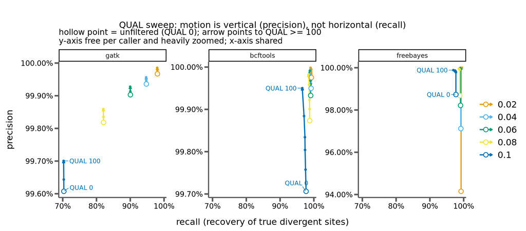

```r
# QUAL sweep as a recall-precision path. Points are ordered by increasing threshold so
# geom_path draws in sweep order and the arrow marks the strict-filter end.
fs <- read_csv("analyses/s06-filtering/results/s06-filter-sweep.csv") %>%
  filter(vtype == "snp", axis == "QUAL") %>%
  mutate(caller = fac(caller), divergence = factor(divergence)) %>%
  arrange(caller, divergence, threshold)

# endpoints used for annotation: hollow marker on the unfiltered point, text labels on the
# two ends of the most-diverged path only (labelling all 5 paths overplots the facet)
fs_unfilt <- filter(fs, threshold == 0)
fs_lab    <- filter(fs, divergence == "0.1", threshold %in% c(0, 100)) %>%
  mutate(lab = paste0("QUAL ", threshold))

ggplot(fs, aes(recall, precision, color = divergence)) +
  geom_path(linewidth = 0.8, arrow = arrow(length = unit(0.10, "cm"), type = "closed")) +
  geom_point(size = 1) +
  geom_point(data = fs_unfilt, shape = 21, fill = "white", size = 2.4, stroke = 0.8) +
  ggrepel::geom_text_repel(data = fs_lab, aes(label = lab), size = 3, show.legend = FALSE,
                           min.segment.length = 0, segment.size = 0.3, box.padding = 0.5) +
  scale_color_manual(values = corecol(pal="wilke",numcol=5), name = "divergence") +
  scale_x_continuous(labels = pct) +
  scale_y_continuous(labels = function(x) scales::percent(x, accuracy = 0.01)) +
  # free y: shared precision axis is dominated by freebayes' unfiltered 94%, which flattens
  # every other path to a dot. x stays shared so the divergence spread is comparable.
  facet_wrap(~caller, nrow = 1, scales = "free_y") +
  labs(x = "recall (recovery of true divergent sites)", y = "precision",
       title = "QUAL sweep: motion is vertical (precision), not horizontal (recall)",
       subtitle = paste0("hollow point = unfiltered (QUAL 0); arrow points to QUAL >= 100\n",
                         "y-axis free per caller and heavily zoomed; x-axis shared")) +
  bartheme() + theme(legend.position = "right")
```

**Read:** every path is ~1 recall-point wide (e.g. gatk at divergence 0.10 moves 70.34 % → 70.27 % recall across the whole QUAL sweep) while precision climbs. The large *horizontal* spread between colours is divergence, not filtering — no cutoff moves you across that gap, because the missing variants were never emitted in the first place. freebayes is the one caller where filtering does real work, and only on the y axis: its unfiltered precision is 94.2 % at divergence 0.02, and the very first cutoff (QUAL ≥ 10) restores it to ~99.98 % at no cost in recall.

The MAPQ (`MQ`) axis is the case where filtering actively hurts, so it gets its own panel — here recall is plotted directly against the threshold, since that is the claim being made:

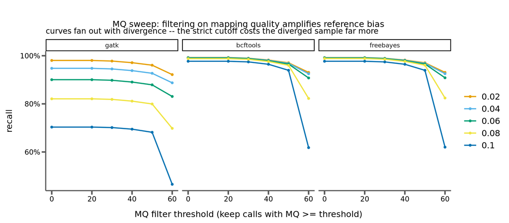

```r
# MQ sweep: recall vs threshold. INFO/MQ for gatk & bcftools, INFO/MQM for freebayes.
# Plotted in absolute recall so the fan-out with divergence (= the amplification) is visible.
fm <- read_csv("analyses/s06-filtering/results/s06-filter-sweep.csv") %>%
  filter(vtype == "snp", axis == "MQ") %>%
  mutate(caller = fac(caller), divergence = factor(divergence)) %>%
  arrange(caller, divergence, threshold)

ggplot(fm, aes(threshold, recall, color = divergence)) +
  geom_line(linewidth = 0.8) + geom_point(size = 1.2) +
  scale_color_manual(values = corecol(pal="wilke",numcol=5), name = "divergence") +
  scale_y_continuous(labels = pct) +
  facet_wrap(~caller, nrow = 1) +
  labs(x = "MQ filter threshold (keep calls with MQ >= threshold)", y = "recall",
       title = "MQ sweep: filtering on mapping quality amplifies reference bias",
       subtitle = "curves fan out with divergence -- the strict cutoff costs the diverged sample far more") +
  bartheme() + theme(legend.position = "right")
```

**Read:** the curves fan out. Going from unfiltered to MQ ≥ 60 costs bcftools 6.2 recall points at divergence 0.02 (99.27 % → 93.07 %) but 35.9 points at divergence 0.10 (97.70 % → 61.81 %); gatk loses 5.9 vs 23.8 points over the same span. Because diverged reads are exactly the reads that map with lower MAPQ, a hard MAPQ filter preferentially deletes the evidence for the variants that were hardest to recover — it makes the reference-bias gap wider, not narrower.

## 7.2 Structural variants — a permanent local blind spot (s07)

Our callers cannot emit SVs, so they are a ~100 % blind spot; and their breakpoints punch a local hole in *small-variant* recovery that iteration cannot fill (the SV is never baked into the consensus). gatk’s hole is deepest (its assembler again):

SIM DATA — chr19, 30× · **s07** · structural variants on a low SNP + indel background · homogeneous divergence

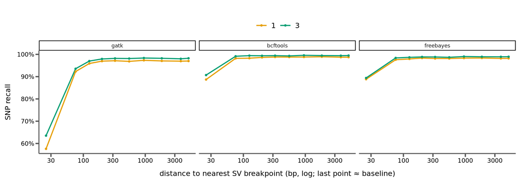

```r
sv <- read_csv("analyses/s07-svs/results/s07-sv-confounder.csv") %>%
  filter(vtype == "snp", bptype == "any", iteration %in% c(1, 3)) %>%
  mutate(caller = fac(caller), iteration = factor(iteration), dist_mid = as.numeric(dist_mid))
ggplot(sv, aes(dist_mid, recall, color = iteration)) +
  geom_line(linewidth = 0.9) + geom_point(size = 1.2) + scale_x_log10() +
  scale_color_manual(values = corecol(pal="wilke",numcol=3)[c(1,3)], name = "iteration") +
  scale_y_continuous(labels = pct) + facet_wrap(~caller, nrow = 1) +
  labs(x = "distance to nearest SV breakpoint (bp, log; last point ≈ baseline)",
       y = "SNP recall") +
  bartheme() + theme(legend.position = "top")
```

## 7.3 Reference repeats — a graded penalty iteration only partly relieves (s08)

Where the reference is repetitive, reads can’t be uniquely placed (low MAPQ → filtered), independent of divergence. Iteration helps partway (lower effective divergence → higher MAPQ) but leaves an irreducible repeat floor:

SIM DATA — chr19, 30× · **s08** · **s01** SNP-only calls, homogeneous divergence, stratified by reference mappability (GenMap)

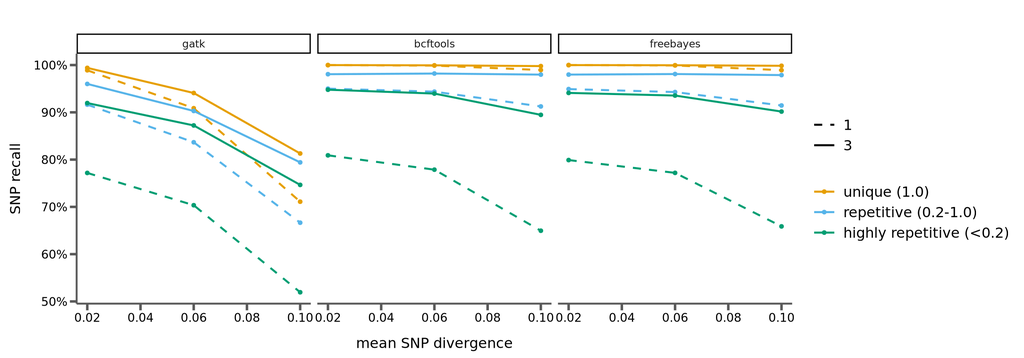

```r
mp <- read_csv("analyses/s08-mappability/results/s08-mappability-recovery.csv") %>%
  mutate(caller = fac(caller), iteration = factor(iteration), divergence = as.numeric(divergence),
         map_bin = factor(map_bin, levels = c("unique (1.0)","repetitive (0.2-1.0)","highly repetitive (<0.2)")))
ggplot(mp, aes(divergence, recall, color = map_bin, linetype = iteration)) +
  geom_line(linewidth = 0.8) + geom_point(size = 1.2) +
  scale_color_manual(values = corecol(pal="wilke",numcol=3), name = "mappability") +
  scale_linetype_manual(values = c(`1`="dashed",`3`="solid"), name = "iteration") +
  scale_y_continuous(labels = pct) + facet_wrap(~caller, nrow = 1) +
  labs(x = "mean SNP divergence", y = "SNP recall") +
  bartheme() + theme(legend.position = "right")
```

# 8 What this means for the paper

- **One mechanism unifies everything.** Reference bias = mapping loss + calling loss; the mapping-vs-calling decomposition (and its per-variant G/decomposition views) is the intellectual core. Every scenario is a shift of that balance.
- **The fix is mechanistic, not a heuristic.** Iteration works by lowering effective divergence, which is exactly why it recovers the calling-limited and divergence-driven mapping-limited losses.
- **Separability is the structural gift.** It lets the paper carry the mechanism on clean homogeneous divergence and treat heterogeneity as one “it generalizes + realistic magnitude” result — you don’t re-derive the mechanism per scenario.
- **The honest boundary.** SVs (blind spot) and repeats (graded, partly relieved) are off-axis reference-structure failures iteration can’t fully address, and filtering can’t recover any of it — this bounds the claim and is a strength, not a caveat.

*Candidate main-text arc:* (1) problem, (2) mechanism (the mapping-vs-calling split + one G panel), (3) fix (recall gains + the flow/decomposition), (4) generalization + hardest variants (separability + indels), (5) limits. Everything else (allele balance, soft-clip, amplitude/scale sweeps, filter axes, SV/repeat detail, replicate seeds) → supplement.